# 99_checks.R

steffi

2021-02-18

Copyright 2021 Province of British Columbia

Licensed under the Apache License, Version 2.0 (the “License”); you may not use this file except in compliance with the License. You may obtain a copy of the License at

http://www.apache.org/licenses/LICENSE-2.0

Unless required by applicable law or agreed to in writing, software distributed under the License is distributed on an “AS IS” BASIS, WITHOUT WARRANTIES OR CONDITIONS OF ANY KIND, either express or implied. See the License for the specific language governing permissions and limitations under the License.

> Render this file with:

> rmarkdown::render(input = “99_checks.R”, output_dir = “share”)

## Preamble

This file checks that the `st_difference()` actually correctly removed overlapping areas in `02_clean.R`. It also establishes that there are some overlaps, which when removed leave little wiggly bits left over.

These could be

1. ignored
2. fixed by using something like st_snap before st_difference
3. removed manually

Finally it shows that there is confusion regarding actual and official areas. And that there seem to be overlapping, yet distinct management areas…

## Load packages

```r
library(tidyverse)
library(sf)
library(patchwork)
library(kableExtra)
```

## Load protected areas

```r
pa2 <- read_rds("data/CPCAD_Dec2020_BC_clean_no_ovlps.rds") %>%
  mutate(area_single2 = as.numeric(st_area(Shape)))
pa1 <- read_rds("data/CPCAD_Dec2020_BC_clean.rds") %>%
  st_transform(crs = st_crs(pa2))
```

pa1 = original clean, pa2 with overlaps removed

```r
pa2_df <- st_set_geometry(pa2, NULL) %>%
  group_by(zone_id, name_e) %>%
  summarize(o_area = unique(o_area),
            area_all = unique(area_all),
            area_all2 = sum(area_single2),
            area_diff = abs(area_all - area_all2))
```

Look for features where a lot of overlap was removed

```r
filter(pa2_df, area_diff > 2000000) %>%
  arrange(desc(area_diff)) %>%
  kable() %>%
  kable_styling()
```

| zone_id | name_e | o_area | area_all | area_all2 | area_diff |
| --- | --- | --- | --- | --- | --- |
| 700100200 | Hecate Strait and Queen Charlotte Sound Glass Sponge Reefs Marine Protected Areas | 90756.8200 | 2409937647 | 9.075610e+08 | 1502376656 |
| 730017000 | Scott Islands Marine National Wildlife Area | 1157065.3457 | 11570860379 | 1.145468e+10 | 116178812 |
| 700300000 | Offshore Pacific Seamounts And Vents Closure | 8253013.6600 | 82530136583 | 8.252356e+10 | 6573142 |
| 591005273 | Tranquille Wildlife Management Area | 253.0000 | 2773968 | 2.737764e+04 | 2746590 |
| 591104501 | Mount Maxwell - Phase II | 273.5258 | 2735258 | 1.461905e+02 | 2735112 |
| 591005093 | Pitt-Addington Marsh Wildlife Management Area | 2972.0000 | 27170619 | 2.462209e+07 | 2548530 |
| 591004727 | East Side Columbia Lake Wildlife Management Area | 7220.0000 | 71622705 | 6.912256e+07 | 2500149 |
| 592000565 | Roberts Bank Wildlife Management Area | 8770.0000 | 87756696 | 8.547293e+07 | 2283770 |

## Hecate Strait and Queen Charlotte Sound

```r
sub_pa1 <- filter(pa1, str_detect(name_e, "Hecate"))
sub_pa2 <- filter(pa2, str_detect(name_e, "Hecate"))

select(sub_pa2, parent_id, zone_id, name_e, oecm, iucn_cat, protdate) %>%
  st_set_geometry(NULL) %>%
  distinct() %>%
  kable() %>%
  kable_styling()
```

|  | parent_id | zone_id | name_e | oecm | iucn_cat | protdate |
| --- | --- | --- | --- | --- | --- | --- |
| 2080 | 700100000 | 700100100 | Hecate Strait and Queen Charlotte Sound Glass Sponge Reefs Marine Protected Areas | No | Yes | 2017 |
| 2081 | 700100000 | 700100200 | Hecate Strait and Queen Charlotte Sound Glass Sponge Reefs Marine Protected Areas | No | Yes | 2017 |

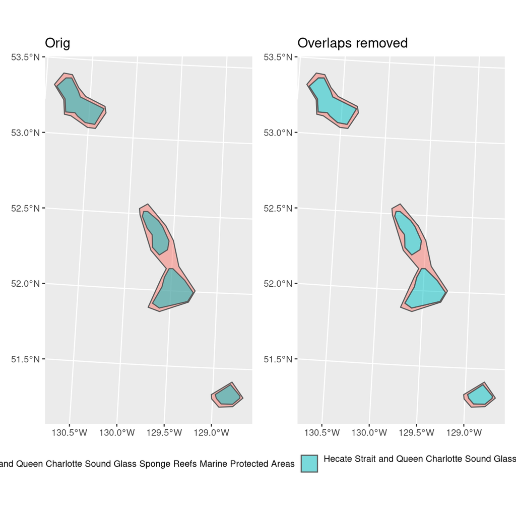

```r
g1 <- ggplot(data = sub_pa1, aes(fill = name_e)) +
  geom_sf(alpha = 0.5) + labs(title = "Orig")
g2 <- ggplot(data = sub_pa2, aes(fill = name_e)) +
  geom_sf(alpha = 0.5) + labs(title = "Overlaps removed")
g1 + g2 + plot_layout(guides = "collect") &
  theme(legend.position = "bottom")
```

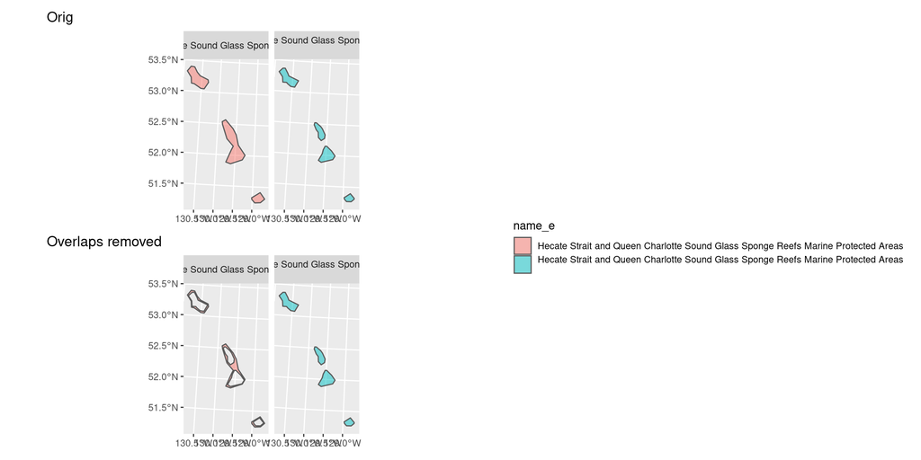

```r
(g1 + facet_wrap(~name_e)) / (g2 + facet_wrap(~name_e)) +
  plot_layout(guides = "collect")
```

Good, areas overlapping removed (something to report?)

## Scott Islands

```r
bbx <- filter(pa2, zone_id == 730017000) %>%
  st_buffer(dist = 1000) %>%
  st_bbox()

sub_pa1 <- st_crop(pa1, bbx)
sub_pa2 <- st_crop(pa2, bbx)
```

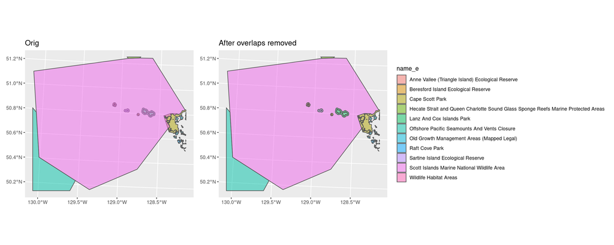

```r
g1 <- ggplot(data = sub_pa1, aes(fill = name_e)) +
  geom_sf(alpha = 0.5) + labs(title = "Orig")
g2 <- ggplot(data = sub_pa2, aes(fill = name_e)) +
  geom_sf(alpha = 0.5) + labs(title = "After overlaps removed")
g1 + g2 + plot_layout(guides = "collect")
```

Cape Scott Park takes priority because more important IUCN Category (II vs. VI)

```r
select(sub_pa2, parent_id, zone_id, name_e, oecm, iucn_cat, protdate) %>%
  st_set_geometry(NULL) %>%
  filter(name_e %in% c("Cape Scott Park",
                       "Scott Islands Marine National Wildlife Area")) %>%
  distinct() %>%
  kable() %>%
  kable_styling()
```

|  | parent_id | zone_id | name_e | oecm | iucn_cat | protdate |
| --- | --- | --- | --- | --- | --- | --- |
| 361 | 590000250 | 592000250 | Cape Scott Park | No | II | 1973 |
| 366 | 590000250 | 591000250 | Cape Scott Park | No | II | 1973 |
| 2077 | 730017000 | 730017000 | Scott Islands Marine National Wildlife Area | No | VI | 2018 |

Small islands parks take priority because Ia > VI

```r
select(sub_pa2, parent_id, zone_id, name_e, oecm, iucn_cat, protdate) %>%
  st_set_geometry(NULL) %>%
  filter(name_e %in% c("Lanz And Cox Islands",
                       "Anne Vallee (Triangle Island) Ecological Reserve",
                       "Beresford Island Ecological Reserve",
                       "Scott Islands Marine National Wildlife Area")) %>%
  distinct() %>%
  kable() %>%
  kable_styling()
```

|  | parent_id | zone_id | name_e | oecm | iucn_cat | protdate |
| --- | --- | --- | --- | --- | --- | --- |
| 38 | 590003012 | 591003012 | Beresford Island Ecological Reserve | No | Ia | 1971 |
| 48 | 590003013 | 591003013 | Anne Vallee (Triangle Island) Ecological Reserve | No | Ia | 1971 |
| 57 | 590003012 | 592003012 | Beresford Island Ecological Reserve | No | Ia | 1971 |
| 59 | 590003013 | 592003013 | Anne Vallee (Triangle Island) Ecological Reserve | No | Ia | 1971 |
| 2077 | 730017000 | 730017000 | Scott Islands Marine National Wildlife Area | No | VI | 2018 |

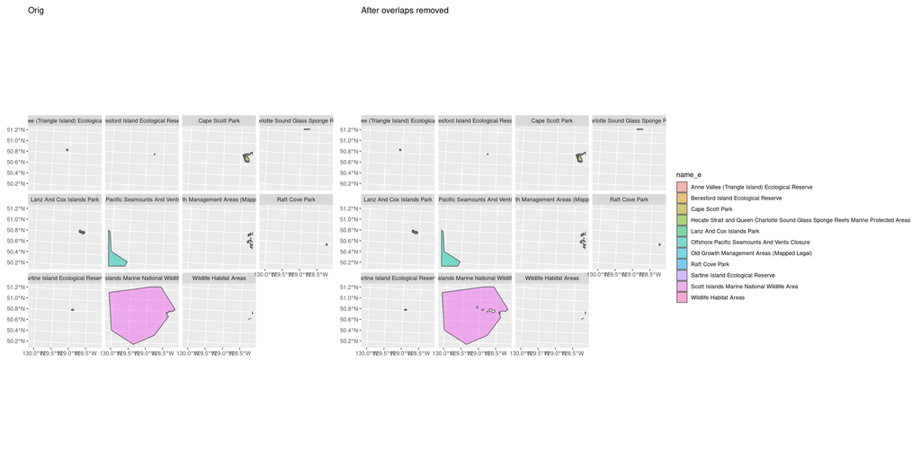

```r
g1 + facet_wrap(~name_e) +
  g2 + facet_wrap(~name_e) +
  plot_layout(guides = "collect")
```

Check out wiggly bits left over

```r
bbx <- c(xmin = 828472.4, xmax = 831002.2, ymin = 640000, ymax = 644300)
g1 <- ggplot(data = filter(sub_pa1, zone_id == 730017000), aes(fill = name_e)) +
  geom_sf(alpha = 0.5) +
  coord_sf(xlim = bbx[1:2], ylim = bbx[3:4]) +
  facet_wrap(~name_e) +
  labs(title = "Orig")
g2 <- ggplot(data = filter(sub_pa2, zone_id == 730017000), aes(fill = name_e)) +
  geom_sf(alpha = 0.5) +
  coord_sf(xlim = bbx[1:2], ylim = bbx[3:4]) +
  facet_wrap(~name_e)+
  labs(title = "After overlaps removed")
```

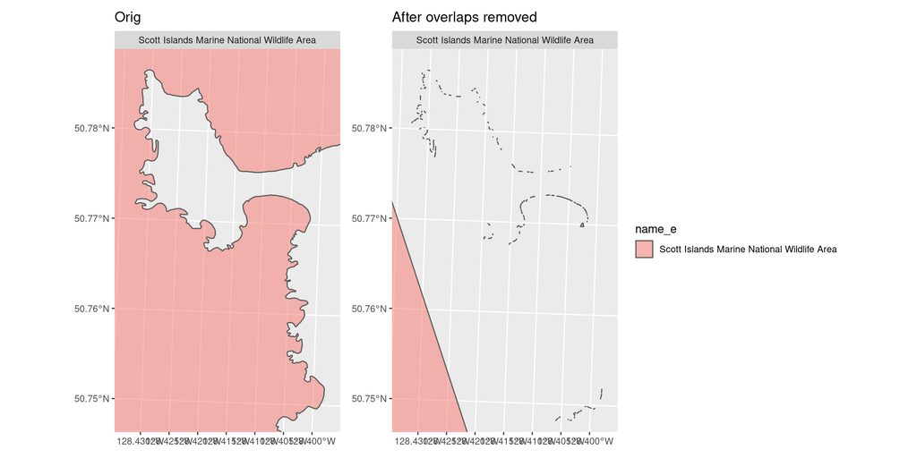

```r
g1 + g2 + plot_layout(guides = "collect")
```

```r
pa2_df %>%
  filter(zone_id == 730017000) %>%
  kable() %>%
  kable_styling()
```

| zone_id | name_e | o_area | area_all | area_all2 | area_diff |
| --- | --- | --- | --- | --- | --- |
| 730017000 | Scott Islands Marine National Wildlife Area | 1157065 | 11570860379 | 11454681567 | 116178812 |

Interestingly, the official area matches best the area BEFORE we removed overlaps…

## Mount Maxwell - Phase II

```r
bbx <- filter(pa2, zone_id == 591104501) %>%
  st_buffer(dist = 1000) %>%
  st_bbox()

sub_pa1 <- st_crop(pa1, bbx)
sub_pa2 <- st_crop(pa2, bbx)
select(sub_pa2, zone_id, name_e, oecm, iucn_cat, protdate) %>%
  kable() %>%
  kable_styling()
```

|  | zone_id | name_e | oecm | iucn_cat | protdate | Shape |
| --- | --- | --- | --- | --- | --- | --- |
| 71 | 591003037 | Mount Maxwell Ecological Reserve | No | Ia | 1972 | POLYGON ((1181127 423779.4,… |
| 1560.1 | 591113900 | Maxwell Lake | No | IV | 2001 | POLYGON ((1181127 425471, 1… |
| 1561 | 591104501 | Mount Maxwell - Phase II | No | IV | 2001 | MULTIPOLYGON (((1179600 426… |

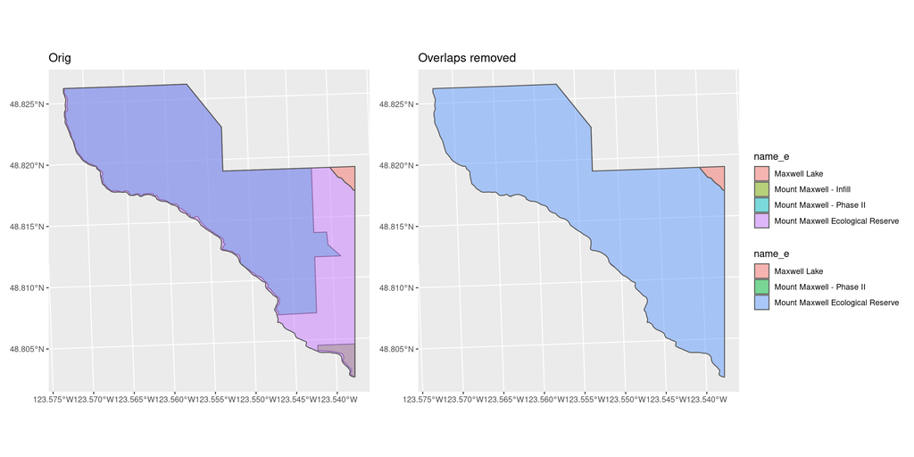

```r
g1 <- ggplot(data = sub_pa1, aes(fill = name_e)) +
  geom_sf(alpha = 0.5) + labs(title = "Orig")
g2 <- ggplot(data = sub_pa2, aes(fill = name_e)) +
  geom_sf(alpha = 0.5) + labs(title = "Overlaps removed")
g1 + g2 + plot_layout(guides = "collect")
```

```r
g11 <- ggplot(data = sub_pa1, aes(fill = name_e)) +
  geom_sf(alpha = 0.5) + labs(title = "Orig") +
  facet_wrap(~name_e, nrow = 1)
g22 <- ggplot(data = sub_pa2, aes(fill = name_e)) +
  geom_sf(alpha = 0.5) + labs(title = "Overlaps removed") +
  facet_wrap(~name_e, nrow = 1)
```

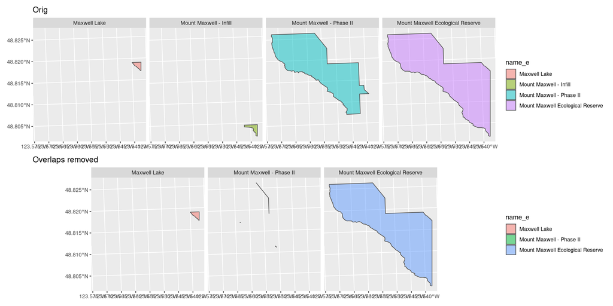

```r
g11 / g22
```

```r
filter(sub_pa2, str_detect(name_e, "Maxwell")) %>%
  select(parent_id, name_e, zone_id, iucn_cat, oecm, o_area, type_e, protdate) %>%
  kable() %>%
  kable_styling()
```

|  | parent_id | name_e | zone_id | iucn_cat | oecm | o_area | type_e | protdate | Shape |
| --- | --- | --- | --- | --- | --- | --- | --- | --- | --- |
| 71 | 590003037 | Mount Maxwell Ecological Reserve | 591003037 | Ia | No | 418.0000 | Ecological Reserve | 1972 | POLYGON ((1181127 423779.4,… |
| 1560.1 | 591113900 | Maxwell Lake | 591113900 | IV | No | 100.0989 | Privately Owned Conservation Area | 2001 | POLYGON ((1181127 425471, 1… |
| 1561 | 591104500 | Mount Maxwell - Phase II | 591104501 | IV | No | 273.5258 | Privately Owned Conservation Area | 2001 | MULTIPOLYGON (((1179600 426… |

A bit confusing, looks like phase II is privately owned, but overlaps extensively with the Ecological Reserve which is public (BC Gov)…

# Official area

Compare new area to Official Area (o_area)

- `o_area` is the Official reported area
- `area_all` is the calculated area *prior* to fixing overlaps
- `area_all2` is the calculated area *after* fixing overlaps
- `area_diff` is the absolute area change after fixing overlaps
- `o_diff1` is the difference between official area and area prior to fixing overlaps
- `o_diff2` is the difference between official area and area after fixing overlaps

There are 2068 distinct areas. Below are listed the ones wherein the Official Area deviates from the calculated area after overlaps have been fixed by more than 5 hectares.

The remaining problems don’t really seem to be related to overlaps…

```r
compare <- pa2_df %>%
  mutate(area_all = area_all / 10000,
         area_all2 = area_all2 / 10000,
         area_diff = area_diff / 10000,
         o_diff1 = o_area - area_all,
         o_diff2 = o_area - area_all2)

compare %>%
  filter(abs(o_diff2) > 5) %>%
  DT::datatable() %>%
  DT::formatRound(columns = 3:5, digits = 0) %>%
  DT::formatRound(columns = 6:8, digits = 2)
```

|  | zone_id | name_e | o_area | area_all | area_all2 | area_diff | o_diff1 | o_diff2 |
| --- | --- | --- | --- | --- | --- | --- | --- | --- |
| 1 | 591000002 | Mount Robson Park | 225285 | 225901.963299025 | 225901.962553261 | 0.000745763969421387 | -616.963299025403 | -616.96255326143 |
| 2 | 591000004 | Kokanee Glacier Park | 32035.4 | 31904.9490460453 | 31904.9508595908 | 0.00181354548931122 | 130.4509539547 | 130.449140409208 |
| 3 | 591000005 | Mount Assiniboine Park | 39013 | 39036.6822136579 | 39032.7386246488 | 3.9435890090704 | -23.6822136578558 | -19.7386246487877 |
| 4 | 591000008 | Golden Ears Park | 62539 | 61637.3337049762 | 61637.2487627808 | 0.084942195391655 | 901.666295023802 | 901.751237219192 |
| 5 | 591000015 | Mount Seymour Park | 3509 | 3551.74129513365 | 3551.74117401578 | 0.000121117871999741 | -42.7412951336487 | -42.7411740157768 |
| 6 | 591000019 | Tweedsmuir Park | 989714 | 987899.378627294 | 987894.078568246 | 5.30005904846191 | 1814.62137270602 | 1819.92143175448 |
| 7 | 591000024 | Wells Gray Park | 541516 | 540413.37017056 | 540413.455442617 | 0.0852720571517944 | 1102.62982944015 | 1102.54455738293 |
| 8 | 591000030 | Little Qualicum Falls Park | 440 | 459.201820038013 | 459.20230987856 | 0.000489840547181666 | -19.2018200380132 | -19.2023098785604 |
| 9 | 591000031 | Stamp River Park | 327 | 346.381642405984 | 346.381571661703 | 7.07442805171013e-05 | -19.3816424059838 | -19.3815716617033 |
| 10 | 591000032 | Wendle Park | 259 | 207.492026368507 | 207.492326584725 | 0.000300216217525303 | 51.5079736314929 | 51.5076734152754 |

[output cut: 456 more lines]

Only in 3 cases did removing overlaps really improve the match between official area and shape area…

```r
compare %>%
  filter(abs(o_diff1) > 5, abs(o_diff2) < 5)%>%
  DT::datatable() %>%
  DT::formatRound(columns = 3:5, digits = 0) %>%
  DT::formatRound(columns = 6:8, digits = 2)
```

|  | zone_id | name_e | o_area | area_all | area_all2 | area_diff | o_diff1 | o_diff2 |
| --- | --- | --- | --- | --- | --- | --- | --- | --- |
| 1 | 591000554 | Upper Elaho Valley Conservancy | 10253 | 10261.3328738598 | 10253.110042236 | 8.22283162379861 | -8.33287385978656 | -0.110042235988658 |
| 2 | 592001028 | Ugwiwa'/Cape Caution Conservancy | 15444 | 15438.7018163264 | 15439.7054839986 | 1.00366767214537 | 5.29818367355983 | 4.2945160014151 |
| 3 | 700100200 | Hecate Strait and Queen Charlotte Sound Glass Sponge Reefs Marine Protected Areas | 90756.82 | 240993.764721245 | 90756.0991515768 | 150237.665569669 | -150236.944721245 | 0.720848423181451 |